# Climate

John Abernethy

2/4/2020

```r
rm(list=ls())
#Get required packages and set wd
options(warn = -1)
library(urca)
library(forecast)
library(ggfortify)
setwd("C:/Users/theca/OneDrive/Desktop/Data sets")
```

```r
#note, remove "Land-ocean: Global means" from file first
giss_temp = read.csv("GISS_temp.csv")
head(giss_temp)
```

|  | Year | Jan | Feb | Mar | Apr | May | Jun | Jul | Aug | Sep | Oct | Nov | Dec | J.D | D.N | DJF | MAM | JJA | SON |
| --- | --- | --- | --- | --- | --- | --- | --- | --- | --- | --- | --- | --- | --- | --- | --- | --- | --- | --- | --- |
| 1 | 1880 | -0.17 | -0.23 | -0.08 | -0.15 | -0.09 | -0.20 | -0.17 | -0.09 | -0.14 | -0.22 | -0.21 | -0.16 | -0.16 | *** | *** | -0.11 | -0.15 | -0.19 |
| 2 | 1881 | -0.18 | -0.13 | 0.04 | 0.06 | 0.07 | -0.17 | 0.01 | -0.02 | -0.14 | -0.20 | -0.17 | -0.06 | -0.07 | -0.08 | -0.16 | 0.06 | -0.06 | -0.17 |
| 3 | 1882 | 0.18 | 0.15 | 0.06 | -0.15 | -0.14 | -0.22 | -0.15 | -0.06 | -0.14 | -0.23 | -0.15 | -0.35 | -0.10 | -0.08 | 0.09 | -0.08 | -0.14 | -0.17 |
| 4 | 1883 | -0.28 | -0.36 | -0.12 | -0.18 | -0.17 | -0.06 | -0.07 | -0.13 | -0.21 | -0.11 | -0.23 | -0.10 | -0.17 | -0.19 | -0.33 | -0.16 | -0.09 | -0.18 |
| 5 | 1884 | -0.12 | -0.08 | -0.36 | -0.39 | -0.34 | -0.34 | -0.32 | -0.27 | -0.27 | -0.24 | -0.32 | -0.30 | -0.28 | -0.26 | -0.1 | -0.36 | -0.31 | -0.28 |
| 6 | 1885 | -0.57 | -0.32 | -0.25 | -0.41 | -0.44 | -0.42 | -0.32 | -0.29 | -0.27 | -0.22 | -0.22 | -0.08 | -0.32 | -0.34 | -0.4 | -0.37 | -0.35 | -0.24 |

```r
tail(giss_temp)
```

|  | Year | Jan | Feb | Mar | Apr | May | Jun | Jul | Aug | Sep | Oct | Nov | Dec | J.D | D.N | DJF | MAM | JJA | SON |
| --- | --- | --- | --- | --- | --- | --- | --- | --- | --- | --- | --- | --- | --- | --- | --- | --- | --- | --- | --- |
| 135 | 2014 | 0.76 | 0.55 | 0.79 | 0.81 | 0.85 | 0.67 | 0.59 | 0.81 | 0.85 | 0.80 | 0.67 | 0.80 | 0.75 | 0.74 | 0.67 | 0.82 | 0.69 | 0.77 |
| 136 | 2015 | 0.86 | 0.90 | 0.96 | 0.77 | 0.79 | 0.82 | 0.75 | 0.83 | 0.85 | 1.08 | 1.06 | 1.16 | 0.90 | 0.87 | 0.85 | 0.84 | 0.80 | 1.00 |
| 137 | 2016 | 1.17 | 1.37 | 1.36 | 1.12 | 0.96 | 0.82 | 0.84 | 1.01 | 0.91 | 0.88 | 0.91 | 0.86 | 1.02 | 1.04 | 1.23 | 1.15 | 0.89 | 0.90 |
| 138 | 2017 | 1.03 | 1.14 | 1.16 | 0.94 | 0.90 | 0.72 | 0.82 | 0.87 | 0.79 | 0.90 | 0.88 | 0.95 | 0.92 | 0.92 | 1.01 | 1.00 | 0.80 | 0.86 |
| 139 | 2018 | 0.82 | 0.85 | 0.90 | 0.90 | 0.82 | 0.78 | 0.82 | 0.77 | 0.80 | 1.01 | 0.83 | 0.92 | 0.85 | 0.85 | 0.87 | 0.87 | 0.79 | 0.88 |
| 140 | 2019 | 0.93 | 0.95 | 1.18 | 1.02 | 0.86 | 0.92 | 0.94 | 0.94 | 0.92 | 1.02 | 1.00 | 1.11 | 0.98 | 0.97 | 0.93 | 1.02 | 0.93 | 0.98 |

```r
giss_temp[1:2, 2:13]
```

|  | Jan | Feb | Mar | Apr | May | Jun | Jul | Aug | Sep | Oct | Nov | Dec |
| --- | --- | --- | --- | --- | --- | --- | --- | --- | --- | --- | --- | --- |
| 1 | -0.17 | -0.23 | -0.08 | -0.15 | -0.09 | -0.20 | -0.17 | -0.09 | -0.14 | -0.22 | -0.21 | -0.16 |
| 2 | -0.18 | -0.13 | 0.04 | 0.06 | 0.07 | -0.17 | 0.01 | -0.02 | -0.14 | -0.20 | -0.17 | -0.06 |

```r
d <- dim(giss_temp)
```

```r
#Here we put the data into a useful form, columns 2 to 13, one row at a time.
k <-1
Temp <- c()
for(i in 1:d[1]){
   for(j in 2:13){
       Temp[k] <- giss_temp[i,j]
       k = k + 1
   }
}
length(Temp)
```

```
## [1] 1680
```

```r
#create a date field
Date <- seq(as.Date("1880/1/6"), as.Date("2019/12/6"), by = "month")
length(Date)
```

```
## [1] 1680
```

```r
#Create dataframe with date and temp:

GISS_df <- data.frame(Date, Temp)
head(GISS_df)
```

|  | Date | Temp |
| --- | --- | --- |
| 1 | 1880-01-06 | -0.17 |
| 2 | 1880-02-06 | -0.23 |
| 3 | 1880-03-06 | -0.08 |
| 4 | 1880-04-06 | -0.15 |
| 5 | 1880-05-06 | -0.09 |
| 6 | 1880-06-06 | -0.20 |

```r
tail(GISS_df)
```

|  | Date | Temp |
| --- | --- | --- |
| 1675 | 2019-07-06 | 0.94 |
| 1676 | 2019-08-06 | 0.94 |
| 1677 | 2019-09-06 | 0.92 |
| 1678 | 2019-10-06 | 1.02 |
| 1679 | 2019-11-06 | 1.00 |
| 1680 | 2019-12-06 | 1.11 |

```r
#Let's make a time series object and plot it:
gisTEMP <- ts(GISS_df$Temp, start=c(1880,1), frequency=12)
gis0HOLD <- window(gisTEMP, start=c(1880,1), end=c(2019,6))   # holding 6 observations
gisFULL <- window(gisTEMP, start=c(1958,3), end=c(2019,12))
gisHOLD <- window(gisTEMP, start=c(1958,3), end=c(2019,6))   # holding 6 observations
```

#Global average temperature plots, from January 1880

Note we are using the full GISS dataset for the ARMA model.We will use a partial GISS dataset with the CO2 data, as it only goes back to March, 1958.

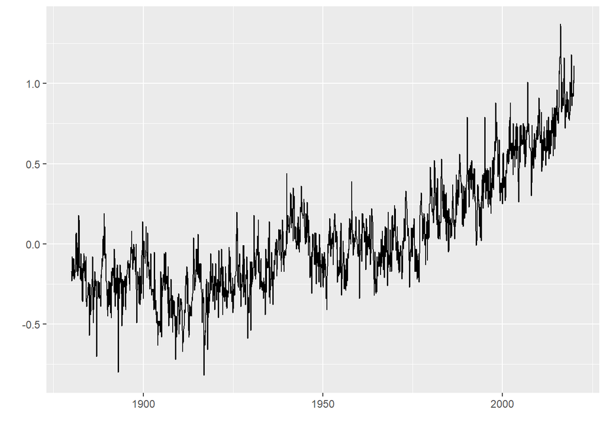

```r
autoplot(gisTEMP)
```

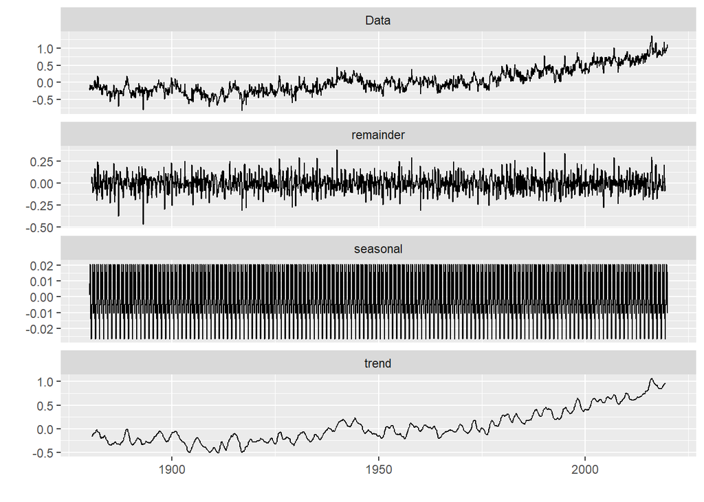

```r
#Decomposition of the time series:
autoplot(decompose(gisTEMP))
```

```r
#Check for unit root and if transformation of data necessary

BoxCox.lambda(gisTEMP)
```

```
## [1] 0.9322902
```

```r
summary(ur.df(gisTEMP, type="trend", lags=30, selectlags = "AIC"))
```

```
##
## ###############################################
## # Augmented Dickey-Fuller Test Unit Root Test #
## ###############################################
##
## Test regression trend
##
##
## Call:
## lm(formula = z.diff ~ z.lag.1 + 1 + tt + z.diff.lag)
##
## Residuals:
##      Min       1Q   Median       3Q      Max
## -0.45908 -0.06523  0.00438  0.06547  0.43539
##
## Coefficients:
##                Estimate Std. Error t value Pr(>|t|)
## (Intercept)  -2.921e-02  9.823e-03  -2.974 0.002987 **
## z.lag.1      -5.225e-02  1.662e-02  -3.143 0.001702 **
## tt            3.972e-05  1.173e-05   3.386 0.000727 ***
## z.diff.lag1  -4.407e-01  2.880e-02 -15.301  < 2e-16 ***
## z.diff.lag2  -2.651e-01  3.068e-02  -8.640  < 2e-16 ***
## z.diff.lag3  -2.300e-01  3.121e-02  -7.367 2.76e-13 ***
## z.diff.lag4  -1.515e-01  3.150e-02  -4.810 1.65e-06 ***
## z.diff.lag5  -1.408e-01  3.141e-02  -4.482 7.91e-06 ***
## z.diff.lag6  -1.125e-01  3.140e-02  -3.582 0.000352 ***
## z.diff.lag7  -1.120e-01  3.126e-02  -3.582 0.000352 ***
## z.diff.lag8  -8.689e-02  3.119e-02  -2.786 0.005396 **
## z.diff.lag9  -8.023e-02  3.105e-02  -2.584 0.009844 **
## z.diff.lag10 -8.062e-02  3.086e-02  -2.612 0.009078 **
## z.diff.lag11 -7.782e-02  3.085e-02  -2.522 0.011750 *
## z.diff.lag12 -2.808e-02  3.085e-02  -0.910 0.362888
## z.diff.lag13 -1.767e-02  3.080e-02  -0.574 0.566278
## z.diff.lag14 -1.978e-02  3.062e-02  -0.646 0.518456
## z.diff.lag15 -1.010e-01  3.046e-02  -3.315 0.000936 ***
## z.diff.lag16 -1.002e-01  3.039e-02  -3.298 0.000993 ***
## z.diff.lag17 -9.948e-02  3.029e-02  -3.284 0.001043 **
## z.diff.lag18 -1.097e-01  3.011e-02  -3.644 0.000277 ***
## z.diff.lag19 -9.002e-02  2.995e-02  -3.006 0.002691 **
## z.diff.lag20 -1.163e-01  2.964e-02  -3.924 9.09e-05 ***
## z.diff.lag21 -7.525e-02  2.933e-02  -2.565 0.010396 *
## z.diff.lag22 -6.245e-02  2.852e-02  -2.190 0.028665 *
## z.diff.lag23 -5.077e-02  2.748e-02  -1.848 0.064831 .
## z.diff.lag24  6.516e-02  2.472e-02   2.635 0.008485 **
## ---
## Signif. codes:  0 '***' 0.001 '**' 0.01 '*' 0.05 '.' 0.1 ' ' 1
##
## Residual standard error: 0.1068 on 1622 degrees of freedom
## Multiple R-squared:  0.2247, Adjusted R-squared:  0.2123
## F-statistic: 18.08 on 26 and 1622 DF,  p-value: < 2.2e-16
##
##
## Value of test-statistic is: -3.1431 4.2127 5.7891
##
## Critical values for test statistics:
##       1pct  5pct 10pct
## tau3 -3.96 -3.41 -3.12
## phi2  6.09  4.68  4.03
## phi3  8.27  6.25  5.34
```

That and looking at the plot, we can determine that the process is probably not mean stationary.

#Let’s look at autocorrelations and partial autocorrelations now

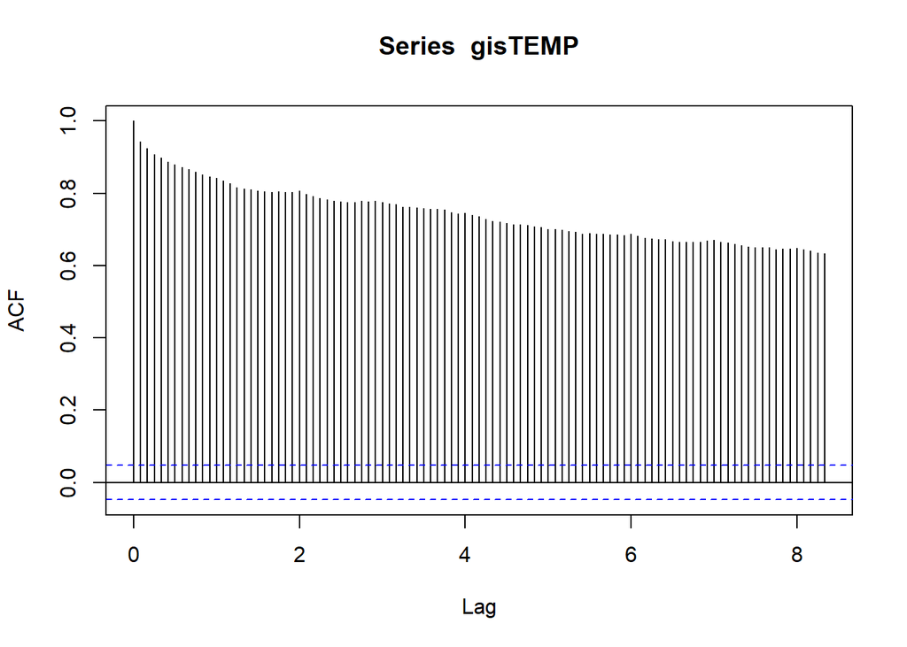

```r
acf(gisTEMP, 100)
```

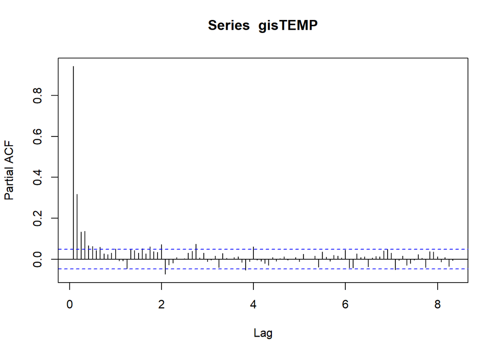

```r
pacf(gisTEMP, 100)
```

Looking at the plots, perhaps a first difference is in order, and the PACF (autocorrelations) with a fairly quick decay, but significant lags staggered through the PACF plot leads me to believe we’ll need maybe one Moving Average component, and a seasonal Moving average component.

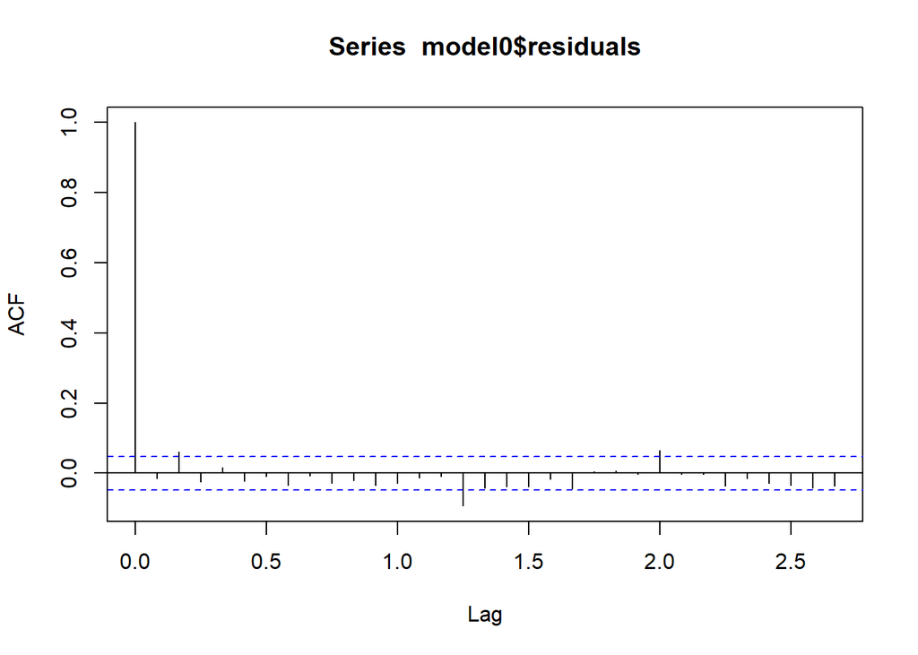

```r
model0 <- Arima(gis0HOLD, order=c(1,1,1), seasonal=c(1,0,1), include.drift = TRUE)
acf(model0$residuals)
```

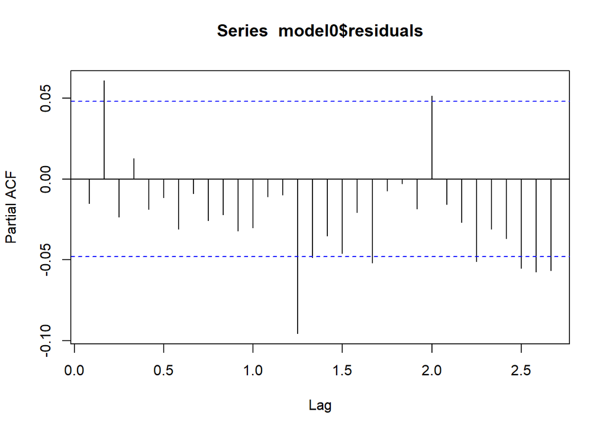

```r
pacf(model0$residuals)
```

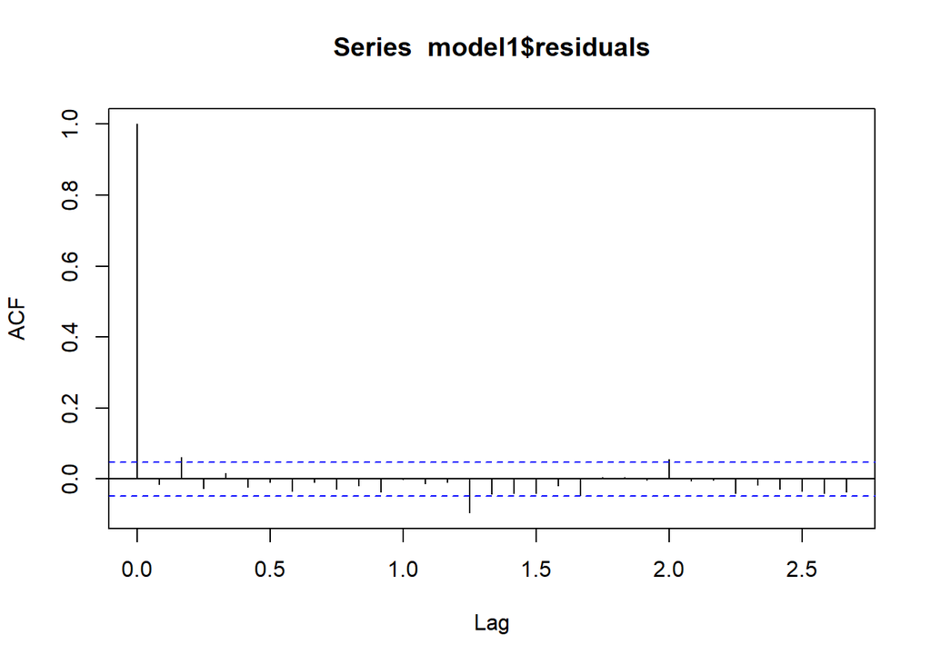

```r
#Maybe we can do a little better.
model1 <- Arima(gis0HOLD, order=c(1,1,1), seasonal=c(1,0,2), include.drift = TRUE)
acf(model1$residuals)
```

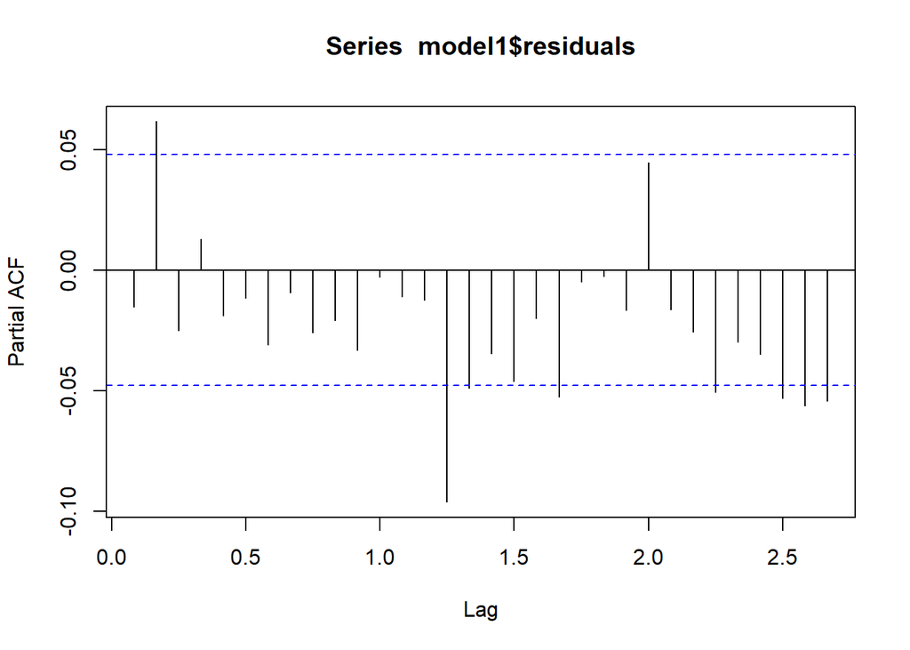

```r
pacf(model1$residuals)
```

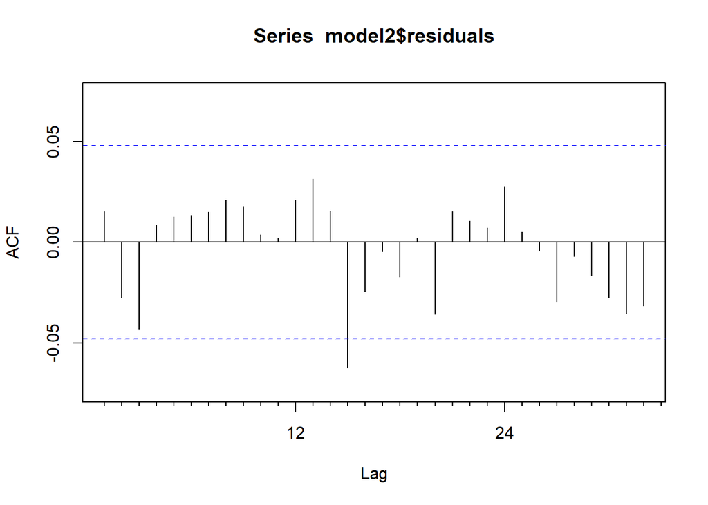

```r
#Model2
model2 <- Arima(gis0HOLD, order=c(2,1,3), seasonal=c(2,0,2), include.drift = TRUE)
Acf(model2$residuals)
```

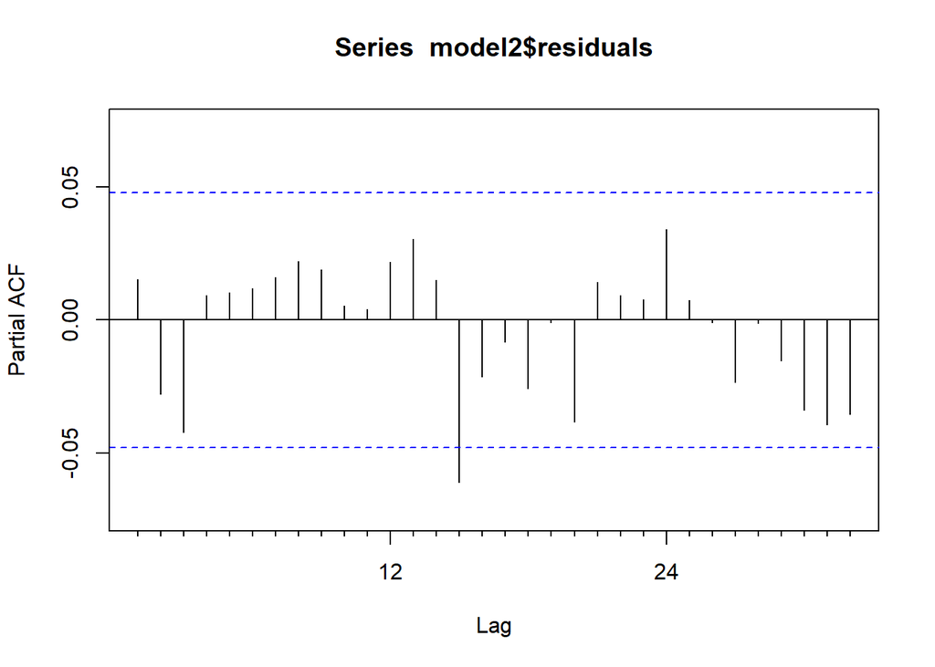

```r
Pacf(model2$residuals)
```

```r
#Slightly better! Maybe the PACF could be cleaned up slightly more, but one significant lag should be within tolerance.
#Let's look at the AIC and BIC value.

AIC(model0)
```

```
## [1] -2694.546
```

```r
AIC(model1)
```

```
## [1] -2694.206
```

```r
AIC(model2)
```

```
## [1] -2738.484
```

```r
BIC(model0)
```

```
## [1] -2662.011
```

```r
BIC(model1)
```

```
## [1] -2656.249
```

```r
BIC(model2)
```

```
## [1] -2678.838
```

Both AIC and BIC point to model 2, which makes sense as it appears we have basically a white noise process left over. Now we have a model $p=2, d=1, q=3$, and $P=2, D=0, Q=2$. Let’s test the validity of the model with the Ljung-Box test:

```r
#Ljung-Box test to determine appropriateness of the model:
Box.test(model2$residuals,30,type="Ljung-Box")
```

```
##
##  Box-Ljung test
##
## data:  model2$residuals
## X-squared = 25.621, df = 30, p-value = 0.6943
```

$H_0: \rho = 0$ for 30 lags, $H_a: \rho \neq 0$ for 30 lags Note the p-value of 0.6943, there is not enough evidence to reject the null hypothesis, and we conclude that the autocorrelation for 30 lags is zero. So this is a good model with which to make predictions.

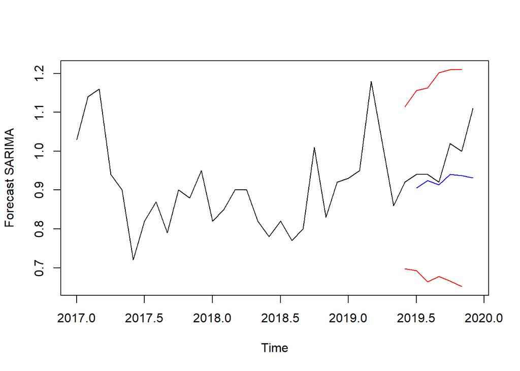

```r
fore=forecast(model2, h=6)
foreSARIMA=fore$mean
upper = ts(fore$upper[,2], start=c(2019,6), frequency=12)
lower = ts(fore$lower[,2], start=c(2019,6), frequency=12)
windowDATA=window(gisFULL, start=c(2017,1))
plot(cbind(fore$mean, upper, lower, windowDATA), plot.type="single", col=c("BLUE", "RED","RED", "BLACK"), ylab="Forecast SARIMA")
```

#Check forecast accuracy with out of sample data

```r
realDATA <- window(gisFULL, start=c(2019,7))
aSARIMA <- accuracy(realDATA, foreSARIMA[1:6])
aSARIMA
```

```
##                   ME       RMSE        MAE       MPE     MAPE
## Test set -0.06309164 0.08550633 0.06309164 -6.777301 6.777301
```

Results look pretty accurate.

#Try a “long range” forecast, like for the year 2050

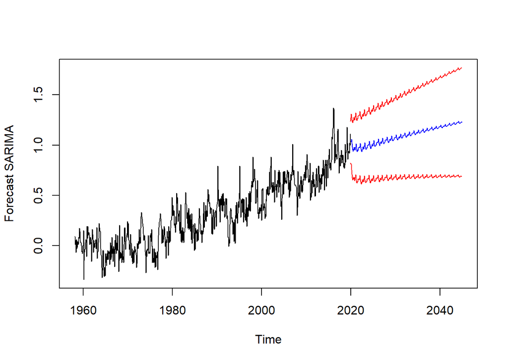

```r
longterm <- Arima(gisTEMP, order=c(2,1,3), seasonal=c(2,0,2), include.drift = TRUE)
fore=forecast(longterm, h=300)
foreSARIMA=fore$mean
upper = ts(fore$upper[,2], start=c(2019,12), frequency=12)
lower = ts(fore$lower[,2], start=c(2019,12), frequency=12)
windowDATA=window(gisFULL, start=c(2017,1))
plot(cbind(fore$mean, upper, lower, gisFULL), plot.type="single", col=c("BLUE", "RED","RED", "BLACK"), ylab="Forecast SARIMA")
```

Note that this long term model for global average temperature is not stable; there is too much divergence between upper and lower bounds

#Now let’s get CO2 data!

```r
#CO2 data here: https://www.esrl.noaa.gov/gmd/ccgg/trends/data.html
CO2 <- read.csv("CO2_csv.csv")
head(CO2)
```

|  | Year | Month | decimal_date | average | interpolated | trend | X.days |
| --- | --- | --- | --- | --- | --- | --- | --- |
| 1 | 1958 | 3 | 1958.208 | 315.71 | 315.71 | 314.62 | -1 |
| 2 | 1958 | 4 | 1958.292 | 317.45 | 317.45 | 315.29 | -1 |
| 3 | 1958 | 5 | 1958.375 | 317.50 | 317.50 | 314.71 | -1 |
| 4 | 1958 | 6 | 1958.458 | -99.99 | 317.10 | 314.85 | -1 |
| 5 | 1958 | 7 | 1958.542 | 315.86 | 315.86 | 314.98 | -1 |
| 6 | 1958 | 8 | 1958.625 | 314.93 | 314.93 | 315.94 | -1 |

```r
tail(CO2)
```

|  | Year | Month | decimal_date | average | interpolated | trend | X.days |
| --- | --- | --- | --- | --- | --- | --- | --- |
| 737 | 2019 | 7 | 2019.542 | 411.77 | 411.77 | 411.41 | 23 |
| 738 | 2019 | 8 | 2019.625 | 409.95 | 409.95 | 411.85 | 29 |
| 739 | 2019 | 9 | 2019.708 | 408.54 | 408.54 | 412.14 | 29 |
| 740 | 2019 | 10 | 2019.792 | 408.53 | 408.53 | 411.95 | 30 |
| 741 | 2019 | 11 | 2019.875 | 410.27 | 410.27 | 412.26 | 25 |
| 742 | 2019 | 12 | 2019.958 | 411.76 | 411.76 | 412.43 | 31 |

```r
#OKay we don't need all these columns, and we can make another date column

Interpolated <- CO2$interpolated
Date <- seq(as.Date("1958/3/6"), as.Date("2019/12/6"), by = "month")
df_CO2 <- data.frame(Date, Interpolated)
head(df_CO2)
```

|  | Date | Interpolated |
| --- | --- | --- |
| 1 | 1958-03-06 | 315.71 |
| 2 | 1958-04-06 | 317.45 |
| 3 | 1958-05-06 | 317.50 |
| 4 | 1958-06-06 | 317.10 |
| 5 | 1958-07-06 | 315.86 |
| 6 | 1958-08-06 | 314.93 |

```r
tail(df_CO2)
```

|  | Date | Interpolated |
| --- | --- | --- |
| 737 | 2019-07-06 | 411.77 |
| 738 | 2019-08-06 | 409.95 |
| 739 | 2019-09-06 | 408.54 |
| 740 | 2019-10-06 | 408.53 |
| 741 | 2019-11-06 | 410.27 |
| 742 | 2019-12-06 | 411.76 |

```r
#Let's make a time series object and plot it:
CO2FULL <- ts(df_CO2$Interpolated, start=c(1958,3), frequency=12)
CO2HOLD <- window(CO2FULL, start=c(1958,3), end=c(2019,6))   # holding 6 observations
```

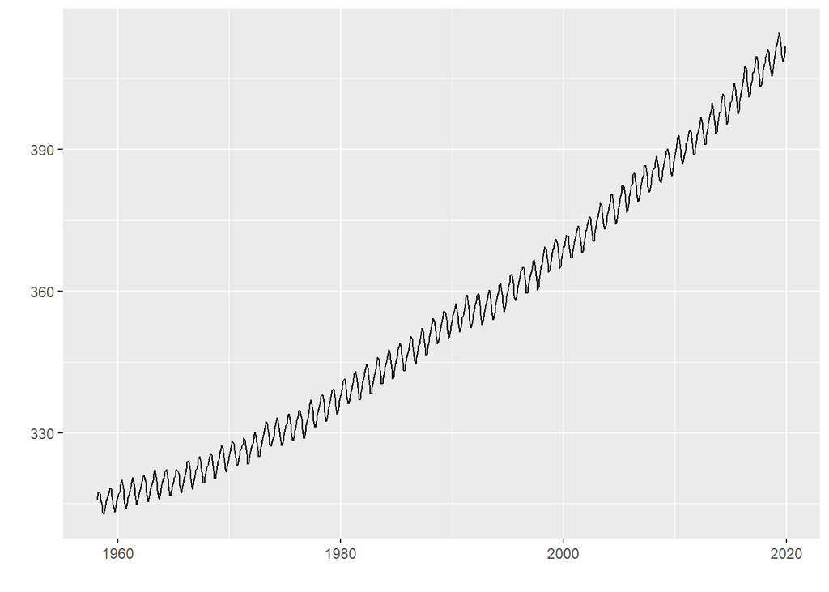

```r
autoplot(CO2FULL)
```

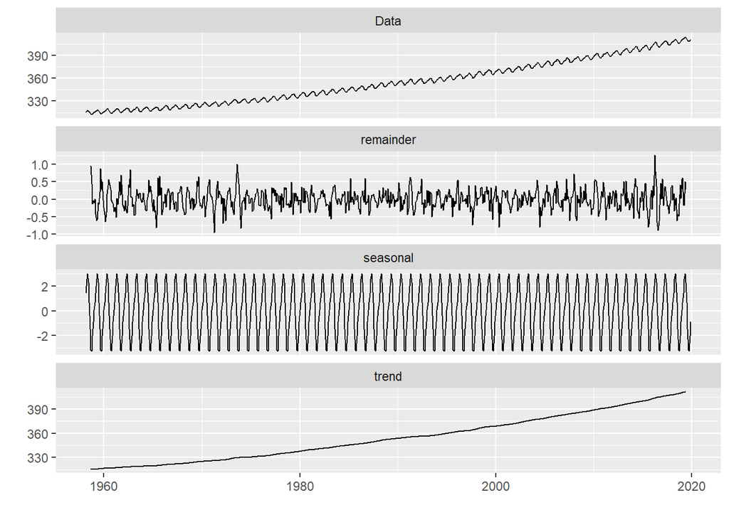

```r
#Decomposition of the two time series:
autoplot(decompose(CO2FULL))
```

```r
BoxCox.lambda(CO2FULL)
```

```
## [1] 0.8027608
```

```r
#UNIT ROOT TEST, check if we need a difference factor.
summary(ur.df(CO2FULL, type="trend", lags=30, selectlags = "AIC"))
```

```
##
## ###############################################
## # Augmented Dickey-Fuller Test Unit Root Test #
## ###############################################
##
## Test regression trend
##
##
## Call:
## lm(formula = z.diff ~ z.lag.1 + 1 + tt + z.diff.lag)
##
## Residuals:
##      Min       1Q   Median       3Q      Max
## -0.90122 -0.21147 -0.01432  0.20190  0.98646
##
## Coefficients:
##                Estimate Std. Error t value Pr(>|t|)
## (Intercept)   0.3691892  1.0927117   0.338 0.735569
## z.lag.1      -0.0007314  0.0035940  -0.204 0.838798
## tt            0.0005876  0.0004786   1.228 0.220021
## z.diff.lag1  -0.3342835  0.0377559  -8.854  < 2e-16 ***
## z.diff.lag2  -0.2368964  0.0390168  -6.072 2.10e-09 ***
## z.diff.lag3  -0.1812914  0.0401260  -4.518 7.35e-06 ***
## z.diff.lag4  -0.1728568  0.0404808  -4.270 2.23e-05 ***
## z.diff.lag5  -0.0846468  0.0404727  -2.091 0.036856 *
## z.diff.lag6  -0.0631831  0.0401122  -1.575 0.115683
## z.diff.lag7  -0.0739333  0.0397402  -1.860 0.063256 .
## z.diff.lag8  -0.0869863  0.0397796  -2.187 0.029103 *
## z.diff.lag9  -0.0416943  0.0395975  -1.053 0.292735
## z.diff.lag10 -0.1296519  0.0395359  -3.279 0.001093 **
## z.diff.lag11  0.0294118  0.0397850   0.739 0.459997
## z.diff.lag12  0.2424251  0.0399146   6.074 2.08e-09 ***
## z.diff.lag13  0.1400371  0.0405974   3.449 0.000596 ***
## z.diff.lag14  0.0242987  0.0400180   0.607 0.543924
## z.diff.lag15 -0.0260860  0.0400642  -0.651 0.515197
## z.diff.lag16 -0.0888702  0.0397334  -2.237 0.025631 *
## z.diff.lag17 -0.1367146  0.0398367  -3.432 0.000636 ***
## z.diff.lag18 -0.0736831  0.0400248  -1.841 0.066064 .
## z.diff.lag19 -0.1545973  0.0399526  -3.870 0.000119 ***
## z.diff.lag20 -0.1563853  0.0403094  -3.880 0.000115 ***
## z.diff.lag21 -0.1686475  0.0406409  -4.150 3.75e-05 ***
## z.diff.lag22 -0.1168004  0.0405558  -2.880 0.004101 **
## z.diff.lag23  0.0031280  0.0400810   0.078 0.937817
## z.diff.lag24  0.1973071  0.0390944   5.047 5.76e-07 ***
## z.diff.lag25  0.1780910  0.0377764   4.714 2.94e-06 ***
## ---
## Signif. codes:  0 '***' 0.001 '**' 0.01 '*' 0.05 '.' 0.1 ' ' 1
##
## Residual standard error: 0.3203 on 683 degrees of freedom
## Multiple R-squared:  0.9353, Adjusted R-squared:  0.9327
## F-statistic: 365.5 on 27 and 683 DF,  p-value: < 2.2e-16
##
##
## Value of test-statistic is: -0.2035 12.4408 12.3131
##
## Critical values for test statistics:
##       1pct  5pct 10pct
## tau3 -3.96 -3.41 -3.12
## phi2  6.09  4.68  4.03
## phi3  8.27  6.25  5.34
```

Note the P-value of 2.2e-16 is not valid for the test. The hypotheses are $H_0: a = 0$, $H_a: a < 0$ Since the tau3 values are less than the calculated tau statistic $-0.2035$ for all significance levels, we fail to reject the null hypothesis that there exists a unit root. Results of the Augmented Dickie-Fuller test say we do need a first difference for the atmospheric CO2 parts-per-million series.

Further note that the Box-cox value, 0.8027608, indicates very slight exponential growth in atmospheric CO2 concentrations. A log transformation of the data is not necessary.

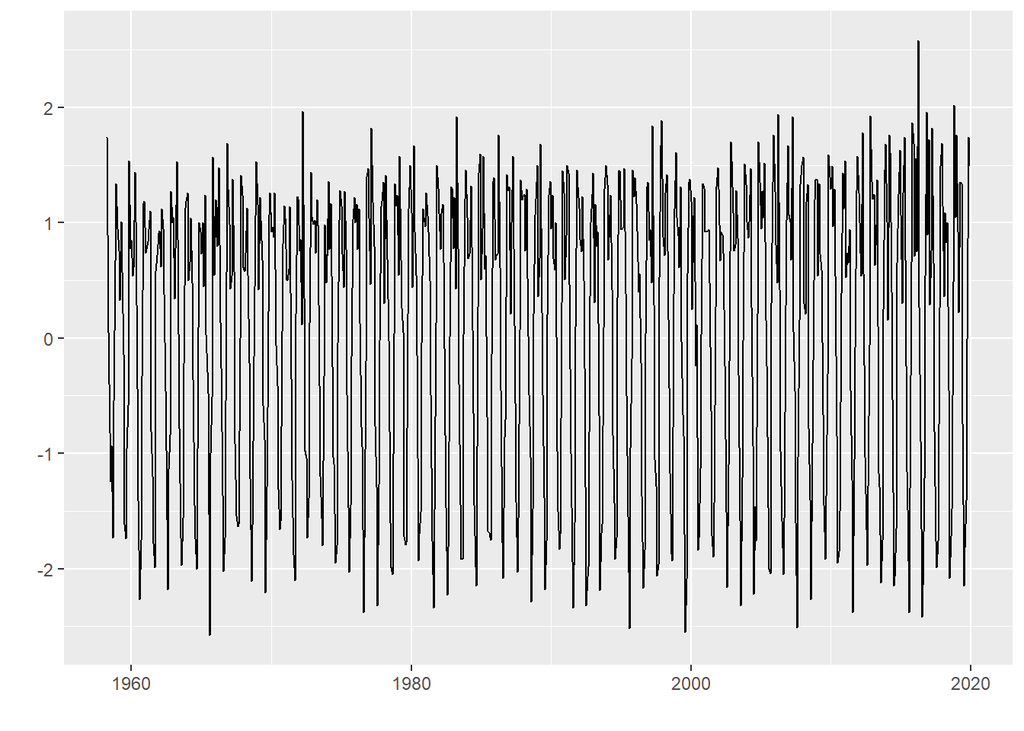

```r
#Let's check the transformed data
autoplot(diff(CO2FULL))
```

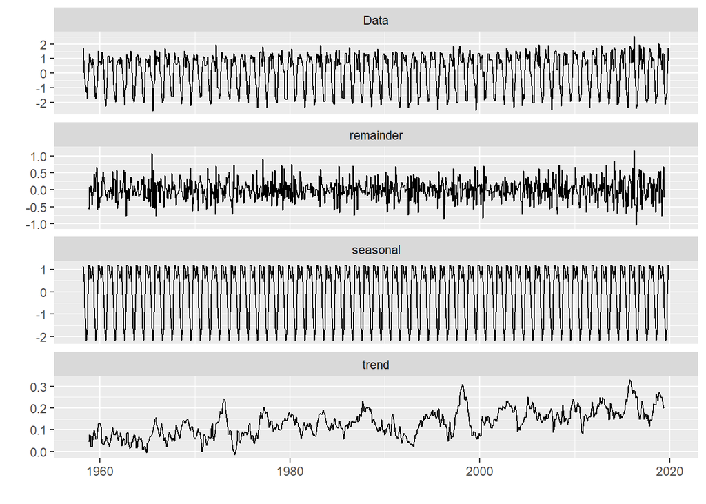

```r
autoplot(decompose(diff(CO2FULL)))
```

#Here we will build a vector autoregression model to see if atmospheric levels of carbon dioxide are a good predictor of global average temperatures.

```r
library(vars)
X=cbind((gisHOLD), diff(CO2HOLD))#note this creates one NA
X[is.na(X)] <- 0
VARselect(X, lag.max=20, type="const")
```

```
## $selection
## AIC(n)  HQ(n)  SC(n) FPE(n)
##     17     13     13     17
##
## $criteria
##                  1            2            3            4            5
## AIC(n) -4.49242518 -4.895319048 -5.018975261 -5.058611916 -5.083646688
## HQ(n)  -4.47762506 -4.870652181 -4.984441648 -5.014211556 -5.029379581
## SC(n)  -4.45409825 -4.831440833 -4.929545761 -4.943631129 -4.943114616
## FPE(n)  0.01119347  0.007481525  0.006611306  0.006354391  0.006197298
##                   6            7            8            9           10
## AIC(n) -5.267366032 -5.624634791 -5.985855163 -6.197672110 -6.394861255
## HQ(n)  -5.203232179 -5.550634191 -5.901987817 -6.103938017 -6.291260416
## SC(n)  -5.101282674 -5.433000147 -5.768669234 -5.954934894 -6.126572754
## FPE(n)  0.005157218  0.003607925  0.002514108  0.002034211  0.001670174
##                  11           12           13           14           15
## AIC(n) -6.397859073 -6.504954082 -6.578258529 -6.584562994 -6.583417304
## HQ(n)  -6.284391487 -6.381619749 -6.445057449 -6.441495168 -6.430482731
## SC(n)  -6.104019286 -6.185563008 -6.233316170 -6.214069349 -6.187372373
## FPE(n)  0.001665192  0.001496094  0.001390368  0.001381653  0.001383265
##                  16           17          18           19           20
## AIC(n) -6.583776876 -6.596594319 -6.59293920 -6.595568313 -6.594586070
## HQ(n)  -6.420975557 -6.423926253 -6.41040439 -6.403166754 -6.392317764
## SC(n)  -6.162180660 -6.149446817 -6.12024041 -6.097318239 -6.070784710
## FPE(n)  0.001382798  0.001365222  0.00137026  0.001366705  0.001368096
```

We will use 13 and 17 lags for testing accuracy with out of sample data.

#Grainger causality test

```r
#Grainger test for 13 lags
grangertest(gisHOLD ~ CO2HOLD, order = 13)
```

|  | Res.Df | Df | F | Pr(>F) |
| --- | --- | --- | --- | --- |
| 1 | 696 | NA | NA | NA |
| 2 | 709 | -13 | 5.35272 | 3.045596e-09 |

```r
#Grainger test for 17 lags
grangertest(gisHOLD ~ CO2HOLD, order = 17)
```

|  | Res.Df | Df | F | Pr(>F) |
| --- | --- | --- | --- | --- |
| 1 | 684 | NA | NA | NA |
| 2 | 701 | -17 | 3.984448 | 1.373299e-07 |

Granger test results: We let $\alpha$ be the coefficient for CO2, the null hypothesis $H_0:$ $\alpha_0 = \alpha_1 = ... = \alpha_{p} = 0$, and the alternative hypothesis $H_a:$ Any one of the $\alpha \neq 0$.

For both the 13 and 17 lag models we reject $H_0$, and hence we can say an increase in atmospheric CO2 concentrations *Granger-causes* an increase in global average temperatures.

```r
VAR13=VAR(X, p=13, type="const")
foreVAR13=forecast(VAR13, h=6)
foreVAR13
```

```
## X.gisHOLD.
##          Point Forecast     Lo 80    Hi 80     Lo 95    Hi 95
## Jul 2019      0.8888940 0.7519741 1.025814 0.6794931 1.098295
## Aug 2019      0.9150757 0.7618848 1.068267 0.6807905 1.149361
## Sep 2019      0.9002263 0.7319418 1.068511 0.6428573 1.157595
## Oct 2019      0.8982490 0.7230601 1.073438 0.6303206 1.166177
## Nov 2019      0.8973711 0.7123810 1.082361 0.6144532 1.180289
## Dec 2019      0.8910863 0.6983174 1.083855 0.5962717 1.185901
##
## diff.CO2HOLD.
##          Point Forecast       Lo 80      Hi 80      Lo 95      Hi 95
## Jul 2019     -1.7770817 -2.20653025 -1.3476332 -2.4338666 -1.1202969
## Aug 2019     -2.1102033 -2.55490432 -1.6655022 -2.7903148 -1.4300917
## Sep 2019     -1.4311792 -1.88087182 -0.9814866 -2.1189247 -0.7434337
## Oct 2019      0.4850689  0.03125127  0.9388866 -0.2089853  1.1791232
## Nov 2019      1.5751527  1.11361852  2.0366868  0.8692971  2.2810083
## Dec 2019      1.5714995  1.10801883  2.0349802  0.8626670  2.2803321
```

```r
foreVAR13$forecast$X.gisHOLD$mean
```

```
##            Jul       Aug       Sep       Oct       Nov       Dec
## 2019 0.8888940 0.9150757 0.9002263 0.8982490 0.8973711 0.8910863
```

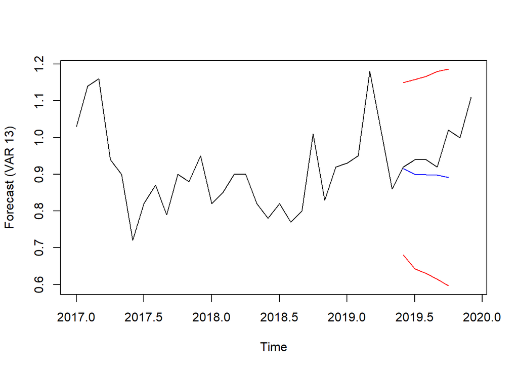

```r
tempFORE13=(foreVAR13$forecast$X.gisHOLD$mean)
meanVAR13=ts(tempFORE13[2:7], start=c(2019,6), frequency=12)
tempFORE13=(foreVAR13$forecast$X.gisHOLD$upper[,2])
upperVAR13=ts(tempFORE13[2:7], start=c(2019,6), frequency=12)
tempFORE13=(foreVAR13$forecast$X.gisHOLD$lower[,2])
lowerVAR13=ts(tempFORE13[2:7], start=c(2019,6), frequency=12)
plot(cbind(meanVAR13, upperVAR13, lowerVAR13, windowDATA), plot.type="single", col=c("BLUE", "RED","RED", "BLACK"), ylab="Forecast (VAR 13)")
```

```r
#Accuracy of the 13-lag model
meanVAR13 <- foreVAR13$forecast$X.gisHOLD$mean
a13 <- accuracy(realDATA, meanVAR13)
a13
```

```
##                   ME      RMSE        MAE       MPE     MAPE      ACF1
## Test set -0.08984961 0.1132131 0.08984961 -10.03793 10.03793 0.2419294
##          Theil's U
## Test set  8.813816
```

```r
VAR17 <- VAR(X, p=17, type="const")
foreVAR17 <- forecast(VAR17, h=6)
foreVAR17
```

```
## X.gisHOLD.
##          Point Forecast     Lo 80    Hi 80     Lo 95    Hi 95
## Jul 2019      0.9005734 0.7641132 1.037034 0.6918755 1.109271
## Aug 2019      0.9097234 0.7573460 1.062101 0.6766823 1.142765
## Sep 2019      0.9169045 0.7495795 1.084229 0.6610030 1.172806
## Oct 2019      0.8985251 0.7245259 1.072524 0.6324162 1.164634
## Nov 2019      0.8990877 0.7157313 1.082444 0.6186683 1.179507
## Dec 2019      0.8912710 0.7001432 1.082399 0.5989662 1.183576
##
## diff.CO2HOLD.
##          Point Forecast       Lo 80      Hi 80      Lo 95      Hi 95
## Jul 2019     -1.7883560 -2.21189324 -1.3648188 -2.4361003 -1.1406117
## Aug 2019     -2.1326361 -2.57817442 -1.6870978 -2.8140282 -1.4512441
## Sep 2019     -1.4453186 -1.89894986 -0.9916874 -2.1390877 -0.7515495
## Oct 2019      0.5526058  0.09498652  1.0102251 -0.1472625  1.2524741
## Nov 2019      1.6303414  1.16804192  2.0926408  0.9233154  2.3373673
## Dec 2019      1.5712257  1.10645907  2.0359923  0.8604265  2.2820249
```

```r
foreVAR17$forecast$X.gisHOLD$mean
```

```
##            Jul       Aug       Sep       Oct       Nov       Dec
## 2019 0.9005734 0.9097234 0.9169045 0.8985251 0.8990877 0.8912710
```

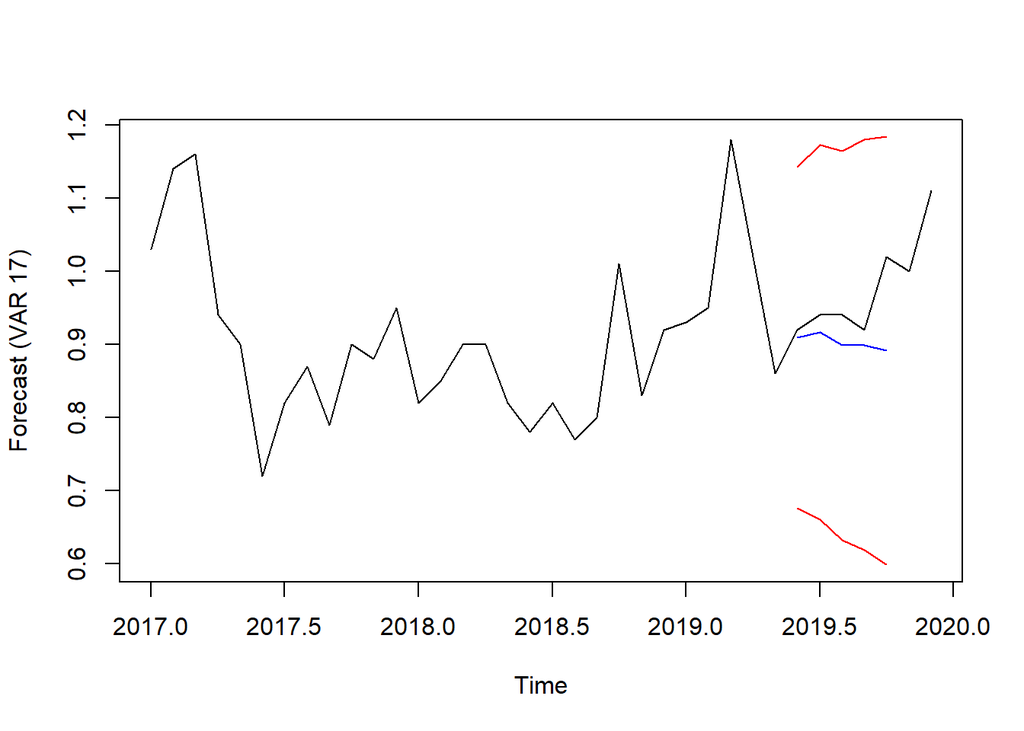

```r
tempFORE17=(foreVAR17$forecast$X.gisHOLD$mean)
meanVAR17=ts(tempFORE17[2:7], start=c(2019,6), frequency=12)
tempFORE17=(foreVAR17$forecast$X.gisHOLD$upper[,2])
upperVAR17=ts(tempFORE17[2:7], start=c(2019,6), frequency=12)
tempFORE17=(foreVAR17$forecast$X.gisHOLD$lower[,2])
lowerVAR17=ts(tempFORE17[2:7], start=c(2019,6), frequency=12)
plot(cbind(meanVAR17, upperVAR17, lowerVAR17, windowDATA), plot.type="single", col=c("BLUE", "RED","RED", "BLACK"), ylab="Forecast (VAR 17)")
```

```r
#Accuracy of the 17-lag model
meanVAR17 <- foreVAR17$forecast$X.gisHOLD$mean
accuVAR17 <- accuracy(realDATA, meanVAR17[1:4])
a17 <- accuracy(realDATA, meanVAR17)
a17
```

```
##                  ME      RMSE       MAE      MPE    MAPE      ACF1 Theil's U
## Test set -0.0856525 0.1119989 0.0856525 -9.55469 9.55469 0.2160847  11.86014
```

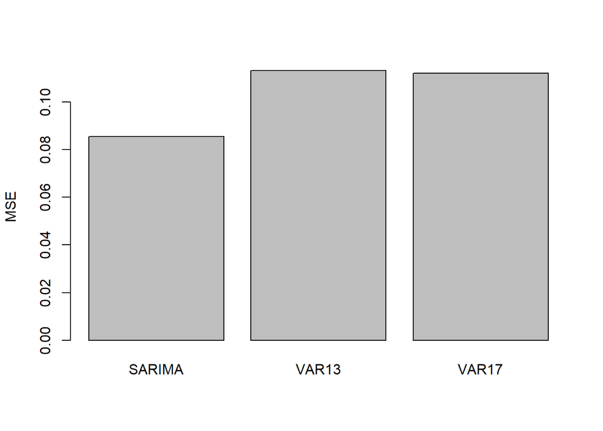

```r
#accuSARIMA = accuracy(realDATA, foreSARIMA[1:4])




barplot(c(aSARIMA[2],a13[2],a17[2]), names.arg = c("SARIMA", "VAR13", "VAR17"),ylab = "MSE")
```

#Add Methane, another greenhouse gas, to the model Methane data from https://www.esrl.noaa.gov/gmd/ccgg/trends_ch4/

```r
methane <- read.csv("methane.csv")
head(methane)
```

|  | year | month | decimal | average | average_unc | trend | trend_unc |
| --- | --- | --- | --- | --- | --- | --- | --- |
| 1 | 1983 | 7 | 1983.542 | 1625.9 | 2.5 | 1634.6 | 1.6 |
| 2 | 1983 | 8 | 1983.625 | 1628.0 | 3.1 | 1635.3 | 1.5 |
| 3 | 1983 | 9 | 1983.708 | 1638.4 | 2.5 | 1635.9 | 1.4 |
| 4 | 1983 | 10 | 1983.792 | 1644.8 | 1.6 | 1636.6 | 1.4 |
| 5 | 1983 | 11 | 1983.875 | 1642.5 | 0.7 | 1637.4 | 1.3 |
| 6 | 1983 | 12 | 1983.958 | 1639.4 | 0.9 | 1638.2 | 1.2 |

```r
tail(methane)
```

|  | year | month | decimal | average | average_unc | trend | trend_unc |
| --- | --- | --- | --- | --- | --- | --- | --- |
| 431 | 2019 | 5 | 2019.375 | 1862.2 | -9.9 | 1866.1 | -9.9 |
| 432 | 2019 | 6 | 2019.458 | 1859.5 | -9.9 | 1867.2 | -9.9 |
| 433 | 2019 | 7 | 2019.542 | 1858.6 | -9.9 | 1868.4 | -9.9 |
| 434 | 2019 | 8 | 2019.625 | 1862.4 | -9.9 | 1869.5 | -9.9 |
| 435 | 2019 | 9 | 2019.708 | 1870.4 | -9.9 | 1870.7 | -9.9 |
| 436 | 2019 | 10 | 2019.792 | 1876.2 | -9.9 | 1871.8 | -9.9 |

```r
#Create methane dataframe we can work with. Note that the data is missing November and December 2019.
Average <- methane$average
Date <- seq(as.Date("1983/7/1"), as.Date("2019/10/6"), by = "month")
CH4 <- data.frame(Date, Average)
CH4FULL <- ts(CH4$Average, start=c(1983,7), frequency=12)
CH4HOLD <- window(CH4FULL, start = c(1983,7), end=c(2019,5))#holding 6 observations

#Adapting the other two series to fit:
CH4TEMPHOLD <- window(gisTEMP, start=c(1983,7), end=c(2019,5))
CH4CO2HOLD <- window(CO2FULL, start=c(1983,7), end=c(2019,5))
```

Let’s plot the Methane data!

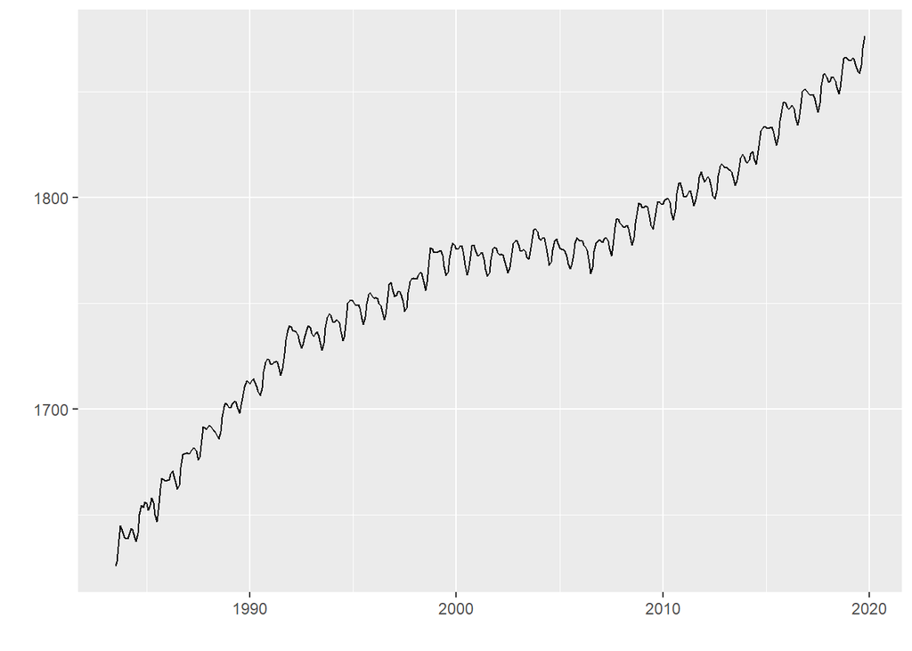

```r
autoplot(CH4FULL)
```

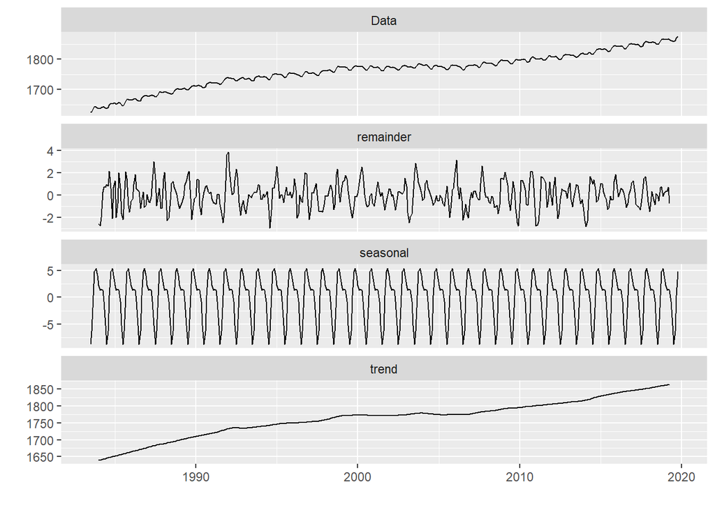

```r
autoplot(decompose(CH4FULL))
```

```r
#Check for unit root and if transformation of data necessary

BoxCox.lambda(CH4FULL)
```

```
## [1] 1.300328
```

```r
summary(ur.df(CH4HOLD, type="trend", lags=30, selectlags = "AIC"))
```

```
##
## ###############################################
## # Augmented Dickey-Fuller Test Unit Root Test #
## ###############################################
##
## Test regression trend
##
##
## Call:
## lm(formula = z.diff ~ z.lag.1 + 1 + tt + z.diff.lag)
##
## Residuals:
##      Min       1Q   Median       3Q      Max
## -1.83473 -0.46298 -0.04302  0.44040  2.59649
##
## Coefficients:
##               Estimate Std. Error t value Pr(>|t|)
## (Intercept)  11.694490   5.606760   2.086  0.03768 *
## z.lag.1      -0.006880   0.003337  -2.061  0.03996 *
## tt            0.002726   0.001357   2.010  0.04518 *
## z.diff.lag1   1.309061   0.050985  25.676  < 2e-16 ***
## z.diff.lag2  -1.796862   0.084492 -21.267  < 2e-16 ***
## z.diff.lag3   1.965147   0.125606  15.645  < 2e-16 ***
## z.diff.lag4  -1.961260   0.161355 -12.155  < 2e-16 ***
## z.diff.lag5   1.698339   0.190813   8.901  < 2e-16 ***
## z.diff.lag6  -1.391061   0.209976  -6.625 1.22e-10 ***
## z.diff.lag7   1.042730   0.221285   4.712 3.47e-06 ***
## z.diff.lag8  -0.750442   0.226606  -3.312  0.00102 **
## z.diff.lag9   0.445278   0.228134   1.952  0.05171 .
## z.diff.lag10 -0.327151   0.227090  -1.441  0.15053
## z.diff.lag11  0.198655   0.225380   0.881  0.37866
## z.diff.lag12  0.185261   0.223000   0.831  0.40664
## z.diff.lag13 -0.182030   0.219140  -0.831  0.40670
## z.diff.lag14  0.287406   0.214611   1.339  0.18133
## z.diff.lag15 -0.221193   0.211684  -1.045  0.29674
## z.diff.lag16  0.183184   0.210430   0.871  0.38458
## z.diff.lag17 -0.159192   0.209984  -0.758  0.44886
## z.diff.lag18  0.132809   0.209545   0.634  0.52661
## z.diff.lag19 -0.172163   0.207325  -0.830  0.40685
## z.diff.lag20  0.115839   0.202001   0.573  0.56668
## z.diff.lag21 -0.078850   0.191072  -0.413  0.68008
## z.diff.lag22  0.012434   0.173395   0.072  0.94287
## z.diff.lag23  0.205807   0.146915   1.401  0.16209
## z.diff.lag24 -0.047580   0.114738  -0.415  0.67862
## z.diff.lag25  0.129724   0.077353   1.677  0.09438 .
## z.diff.lag26 -0.117869   0.047872  -2.462  0.01426 *
## ---
## Signif. codes:  0 '***' 0.001 '**' 0.01 '*' 0.05 '.' 0.1 ' ' 1
##
## Residual standard error: 0.7153 on 371 degrees of freedom
## Multiple R-squared:  0.9543, Adjusted R-squared:  0.9508
## F-statistic: 276.5 on 28 and 371 DF,  p-value: < 2.2e-16
##
##
## Value of test-statistic is: -2.0615 2.9963 2.1255
##
## Critical values for test statistics:
##       1pct  5pct 10pct
## tau3 -3.98 -3.42 -3.13
## phi2  6.15  4.71  4.05
## phi3  8.34  6.30  5.36
```

Further note, from the Box Cox test we see there is no need for a log transformation of the data.

#Vector autoregression with temperature explained by CO2 and CH4

```r
X <- cbind((CH4TEMPHOLD), CH4HOLD, diff(CH4CO2HOLD))#note this creates one NA
X[is.na(X)] <- 0
VARselect(X, lag.max=20, type="const")
```

```
## $selection
## AIC(n)  HQ(n)  SC(n) FPE(n)
##     14     13     10     14
##
## $criteria
##                  1           2            3            4            5
## AIC(n) -2.99867916 -3.96718166 -4.868341248 -5.135764986 -5.318355192
## HQ(n)  -2.95226435 -3.88595575 -4.752304234 -4.984916867 -5.132695970
## SC(n)  -2.88134797 -3.76185208 -4.575013276 -4.754438622 -4.849030437
## FPE(n)  0.04985296  0.01892689  0.007686326  0.005882922  0.004901387
##                   6            7            8             9            10
## AIC(n) -5.833660359 -6.237938642 -6.703317429 -6.9444925730 -7.0538616384
## HQ(n)  -5.613190032 -5.982657211 -6.413224893 -6.6195889335 -6.6941468947
## SC(n)  -5.276337213 -5.592617104 -5.969997499 -6.1231742518 -6.1445449257
## FPE(n)  0.002927921  0.001954479  0.001227389  0.0009645408  0.0008648102
##                   11            12            13            14            15
## AIC(n) -7.0276654745 -7.1267274813 -7.1738722109 -7.1748800264 -7.1586002456
## HQ(n)  -6.6331396265 -6.6973905291 -6.7097241544 -6.6759208656 -6.6248299807
## SC(n)  -6.0303503702 -6.0414139855 -6.0005603235 -5.9135697473 -5.8092915750
## FPE(n)  0.0008880091  0.0008045229  0.0007677718  0.0007673447  0.0007803446
##                   16            17            18            19            20
## AIC(n) -7.1343199318 -7.1166612388 -7.0925776477 -7.0747758367 -7.0566065584
## HQ(n)  -6.5657385626 -6.5132687654 -6.4543740701 -6.4017611548 -6.3487807723
## SC(n)  -5.6970128696 -5.5913557851 -5.4792738025 -5.3734735999 -5.2673059301
## FPE(n)  0.0007999978  0.0008147972  0.0008352891  0.0008510097  0.0008674263
```

We will just use the 14 lag model. Let’s use the Grainger causality test to check the validity of the model

```r
#Grainger test for 15 lags
var<-VAR(X, p=14, season=12)
causality(var, cause = c("CH4HOLD", "diff.CH4CO2HOLD."))
```

```
## $Granger
##
##  Granger causality H0: CH4HOLD diff.CH4CO2HOLD. do not Granger-cause
##  X.CH4TEMPHOLD.
##
## data:  VAR object var
## F-Test = 1.8821, df1 = 28, df2 = 1089, p-value = 0.003761
##
##
## $Instant
##
##  H0: No instantaneous causality between: CH4HOLD diff.CH4CO2HOLD. and
##  X.CH4TEMPHOLD.
##
## data:  VAR object var
## Chi-squared = 1.0103, df = 2, p-value = 0.6034
```

Note I had to employ a different causality test for a multivariate set. Granger test results: We let $\alpha$ be the coefficient for CO2, and $\beta$ be the coefficient for CH4 (methane). The null hypothesis $H_0:$ $\alpha_0 = \alpha_1 = ... = \alpha_{p} = 0$ **AND** $\beta_0 = \beta_1 = ... = \beta_{p} = 0$. the alternative hypothesis $H_a:$ Any one of the $\alpha \neq 0$ **OR** any one of the $\beta \neq 0$.

For the 14 lag model we reject $H_0$, and hence we can say an increase in atmospheric CO2 concentrations **AND** and increase in atmospheric CH4 (methane) concentrations *Granger-causes* an increase in global average temperatures. Further note, there is a test for instantaneous causality. We are not interested in this one.

#Predictions with Methane and CO2 on out of sample data (2019-June to 2019-Nov)

```r
VAR14 <- VAR(X, p=14, type="const")
foreVAR14 <- forecast(VAR14, h=6)
#foreVAR14
#foreVAR14$forecast$X.CH4TEMPHOLD$mean
```

```r
#Accuracy of the 14-lag model
realDATA <- window(gisFULL, start=c(2019,6), end=c(2019,11))
meanVAR14 <- foreVAR14$forecast$X.CH4TEMPHOLD$mean
accuVAR14 <- accuracy(realDATA, meanVAR14[1:4])
a14 <- accuracy(realDATA, meanVAR17)
a14
```

```
##                   ME       RMSE        MAE       MPE     MAPE      ACF1
## Test set -0.05903719 0.07405426 0.05903719 -6.557378 6.557378 0.1295525
##          Theil's U
## Test set  7.425875
```

That is a very small MSE!

```r
VAR14 <- VAR(X, p=14, type="const")
foreVAR14_300 <- forecast(VAR14, h=300)
#foreVAR14_300
#foreVAR14_300$forecast$X.CH4TEMPHOLD$upper[,2]
```

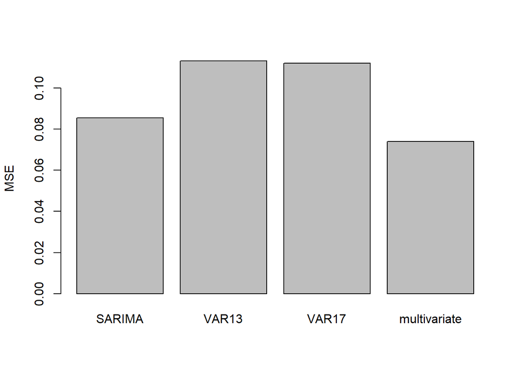

```r
barplot(c(aSARIMA[2],a13[2],a17[2], a14[2]), names.arg = c("SARIMA", "VAR13", "VAR17", "multivariate"),ylab = "MSE")
```

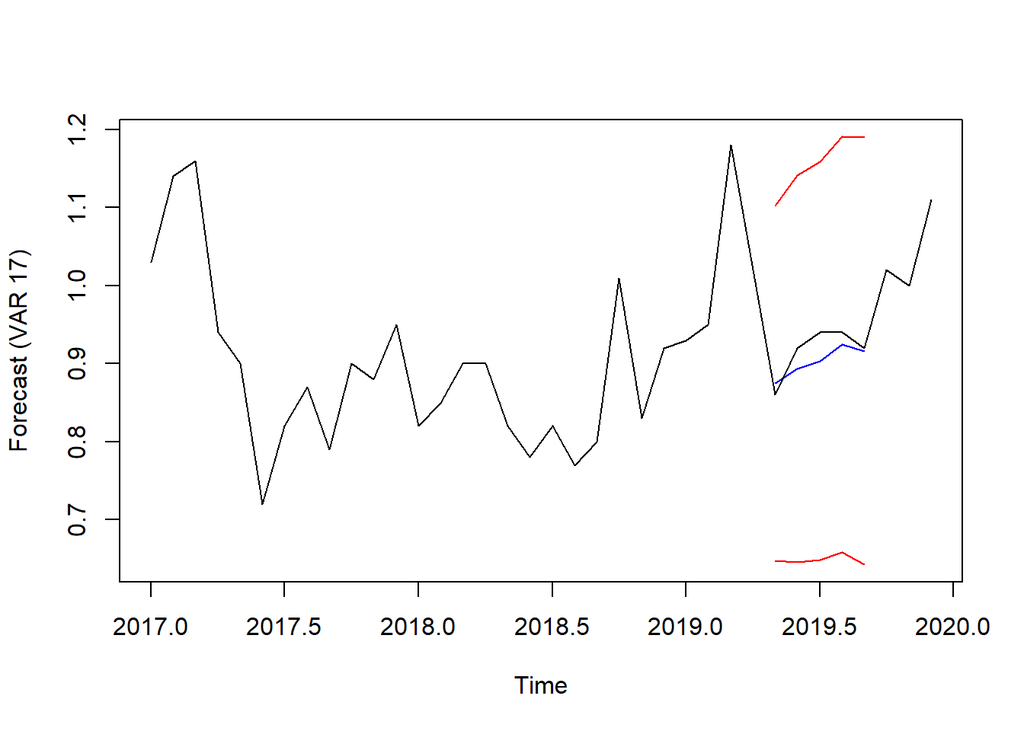

```r
tempFORE14=(foreVAR14$forecast$X.CH4TEMPHOLD$mean)
meanVAR14=ts(tempFORE14[2:7], start=c(2019,5), frequency=12)
tempFORE14=(foreVAR14$forecast$X.CH4TEMPHOLD$upper[,2])
upperVAR14=ts(tempFORE14[2:7], start=c(2019,5), frequency=12)
tempFORE14=(foreVAR14$forecast$X.CH4TEMPHOLD.$lower[,2])
lowerVAR14=ts(tempFORE14[2:7], start=c(2019,5), frequency=12)
plot(cbind(meanVAR14, upperVAR14, lowerVAR14, windowDATA), plot.type="single", col=c("BLUE", "RED","RED", "BLACK"), ylab="Forecast (VAR 17)")
```

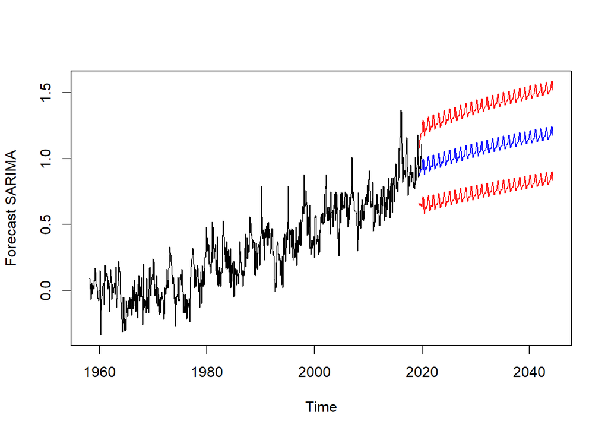

```r
foreVAR14_300 <- forecast(VAR14, h=300)
#foreVAR14_300
foreMEAN <- foreVAR14_300$forecast$X.CH4TEMPHOLD.$mean
foreUPPER <- foreVAR14_300$forecast$X.CH4TEMPHOLD.$upper[,2]
foreLOWER <- foreVAR14_300$forecast$X.CH4TEMPHOLD.$lower[,2]
windowDATA=window(gisFULL, start=c(2017,1), end=c(2019,11))
plot(cbind(foreMEAN, foreUPPER, foreLOWER, gisFULL), plot.type="single", col=c("BLUE", "RED","RED", "BLACK"), ylab="Forecast SARIMA")
```